# ANN - LendingClub (DataSet Kaggle)

# Sommaire

- Importation des librairies
- Chargement des données
- 1 - Analyse exploratoire
- 2 - Pré-traitement des données
- 3 - Création du modèle
- 4 - Evaluation de la performance
- 5 - Test de validation
- 6 - Amélioration du modèle
- 7 - Fonction de prédiction

# Importation des librairies

```python
import pandas as pd
import numpy as np
import matplotlib.pyplot as plt
import seaborn as sns
import pandas as pd

import warnings
warnings.simplefilter(action='ignore', category=FutureWarning)
```

# Chargement des données

```python
df = pd.read_csv('data.csv')
```

```python
df.info()
```

```
<class 'pandas.core.frame.DataFrame'>
RangeIndex: 396030 entries, 0 to 396029
Data columns (total 27 columns):
 #   Column                Non-Null Count   Dtype
---  ------                --------------   -----
 0   loan_amnt             396030 non-null  float64
 1   term                  396030 non-null  object
 2   int_rate              396030 non-null  float64
 3   installment           396030 non-null  float64
 4   grade                 396030 non-null  object
 5   sub_grade             396030 non-null  object
 6   emp_title             373103 non-null  object
 7   emp_length            377729 non-null  object
 8   home_ownership        396030 non-null  object
 9   annual_inc            396030 non-null  float64
```

[output cut: 19 more lines]

# 1 - Analyse exploratoire

```python
sns.set(rc = {'figure.figsize':(16,8)})
```

## Label à prédire

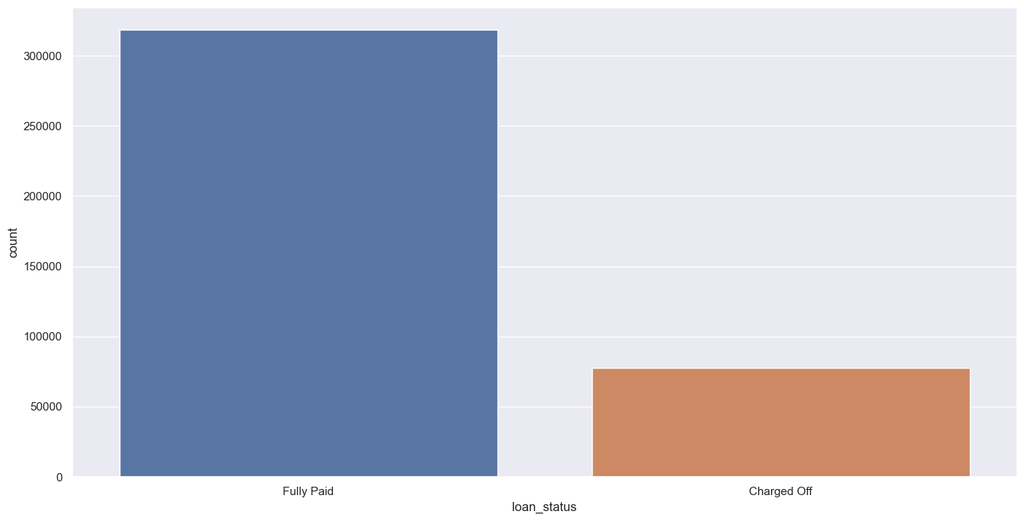

```python
sns.countplot(data= df,
              x= 'loan_status')
plt.show()
```

Les données ne sont pas équilibrées, il est donc important d'avoir de bon résultats pour précision et rappel

## Distribution de loan_amnt

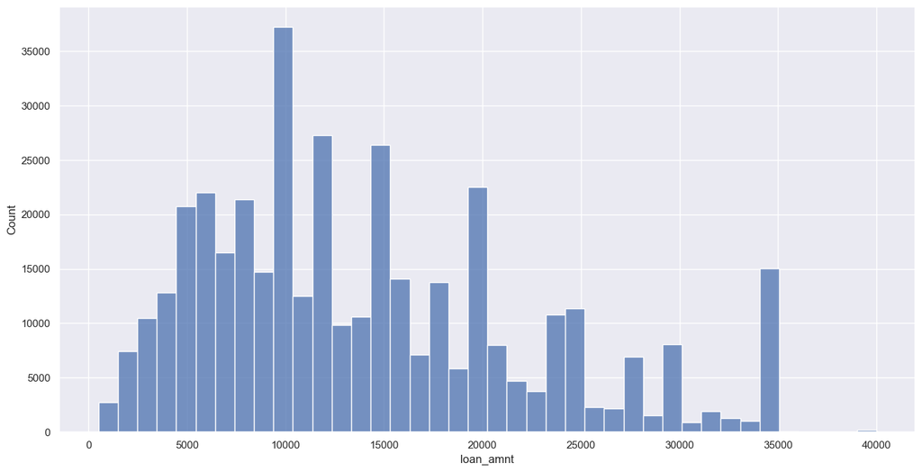

```python
sns.histplot(df['loan_amnt'],
             bins= 40)
plt.show()
```

## Corrélations

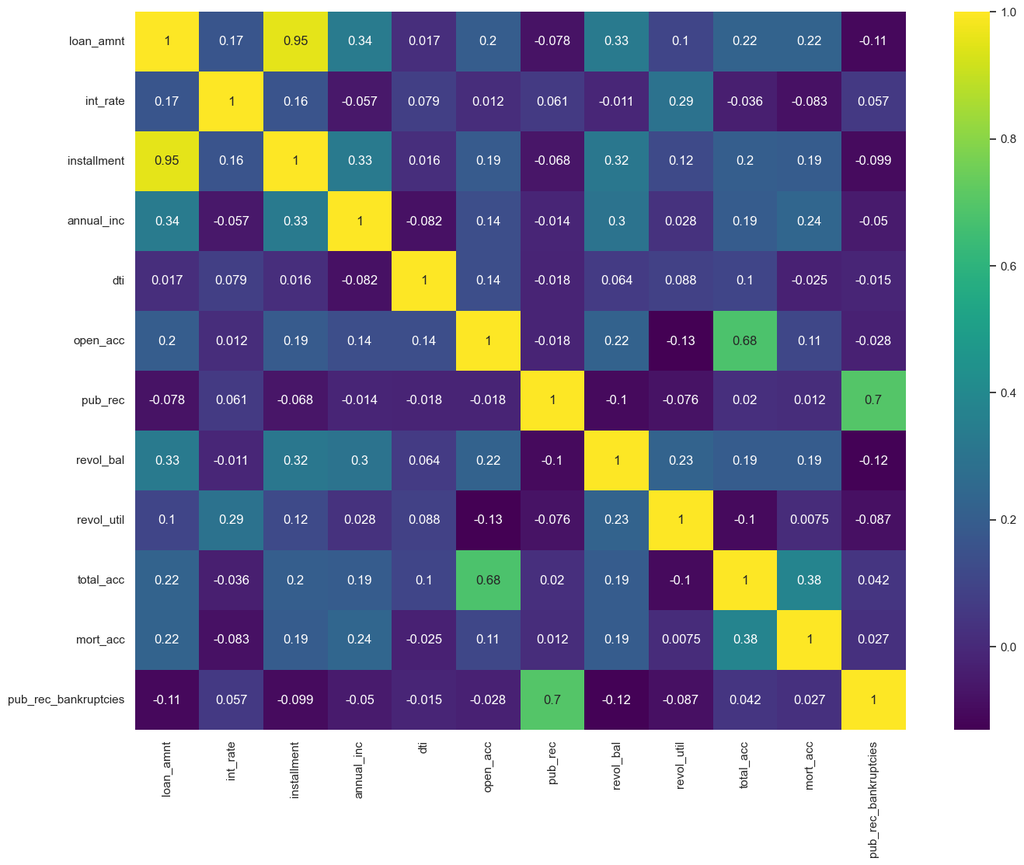

```python
plt.figure(figsize=(16, 12))
sns.heatmap(df.corr(),
            annot= True,
            cmap= 'viridis')
plt.show()
```

On observe une corrélation très importante avec installment

## Distribution de installment

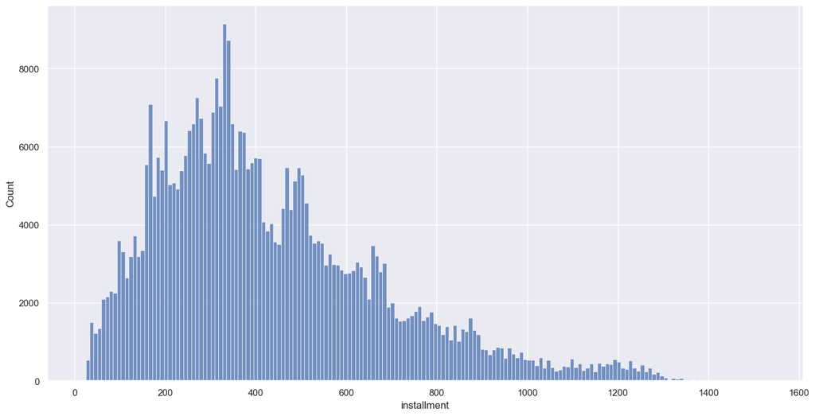

```python
sns.histplot(data= df,
             x= 'installment')
plt.show()
```

## Dispersion de installment

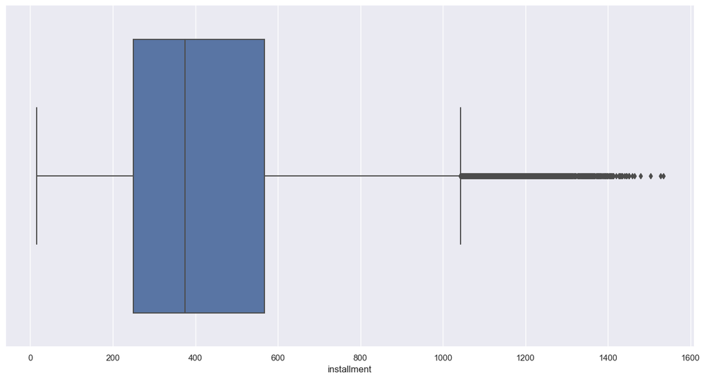

```python
sns.boxplot(data= df,
            x= 'installment'
            )
plt.show()
```

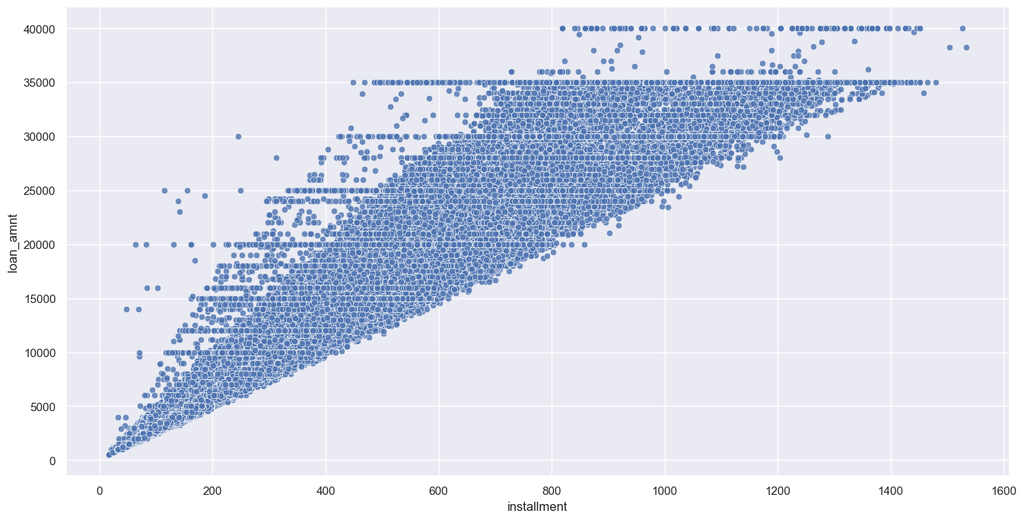

```python
sns.scatterplot(data= df,
                x= 'installment',
                y= 'loan_amnt',
                alpha= 0.8)
plt.show()
```

## Corrélation entre loan_status et loan_amnt

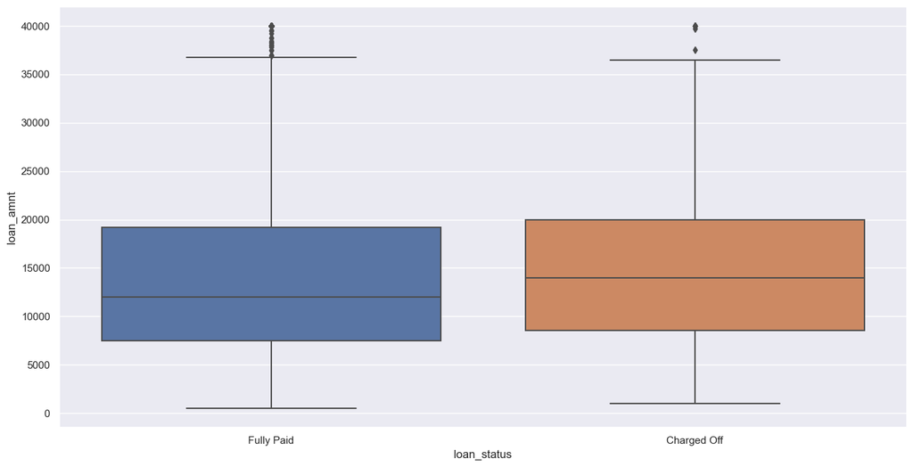

```python
sns.boxplot(data= df,
            x= 'loan_status',
            y= 'loan_amnt'
            )
plt.show()
```

## Analyse statistique de loan_status

```python
df.groupby('loan_status')['loan_amnt'].describe()
```

| loan_status | count | mean | std | min | 25% | 50% | 75% | max |
| --- | --- | --- | --- | --- | --- | --- | --- | --- |
| Charged Off | 77673.0 | 15126.300967 | 8505.090557 | 1000.0 | 8525.0 | 14000.0 | 20000.0 | 40000.0 |
| Fully Paid | 318357.0 | 13866.878771 | 8302.319699 | 500.0 | 7500.0 | 12000.0 | 19225.0 | 40000.0 |

```python
sorted(df.grade.unique())
```

```
['A', 'B', 'C', 'D', 'E', 'F', 'G']
```

```python
sorted(df.sub_grade.unique())
```

```
['A1',
 'A2',
 'A3',
 'A4',
 'A5',
 'B1',
 'B2',
 'B3',
 'B4',
 'B5',
 'C1',
 'C2',
 'C3',
 'C4',
 'C5',
 'D1',
 'D2',
 'D3',
 'D4',
 'D5',
 'E1',
 'E2',
 'E3',
 'E4',
 'E5',
 'F1',
 'F2',
 'F3',
 'F4',
 'F5',
 'G1',
 'G2',
 'G3',
 'G4',
 'G5']
```

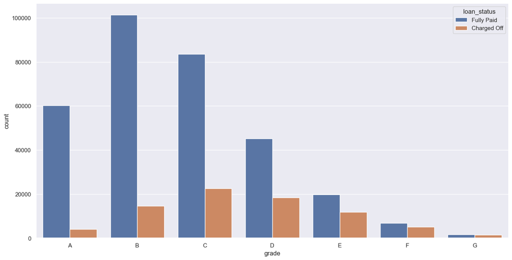

```python
sns.countplot(data= df.sort_values('grade'),
              x = 'grade',
              hue= 'loan_status')
plt.show()
```

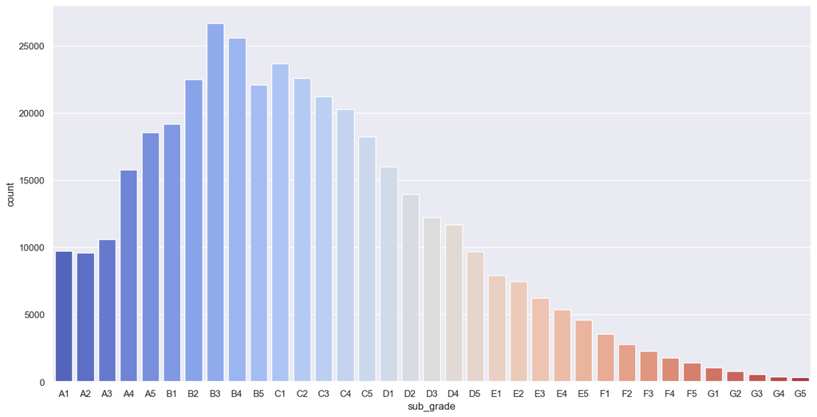

```python
sns.countplot(data= df.sort_values('sub_grade'),
              x = 'sub_grade',
              palette= 'coolwarm')
plt.show()
```

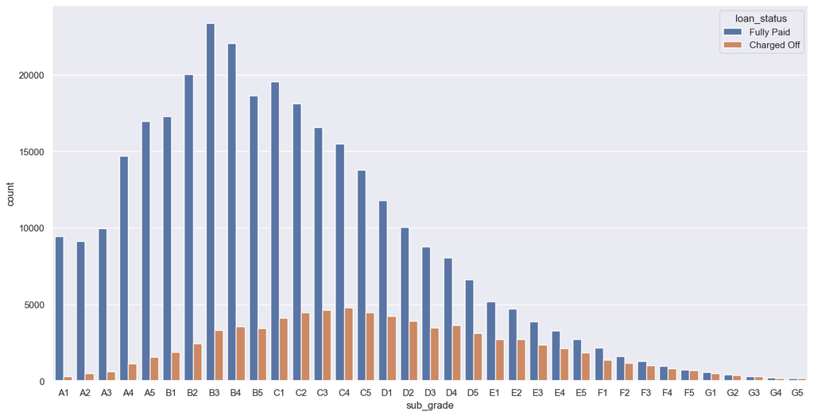

```python
sns.countplot(data= df.sort_values('sub_grade'),
              x = 'sub_grade',
              hue= 'loan_status')
plt.show()
```

## On observe un mauvais taux de remboursement sur les note F et G

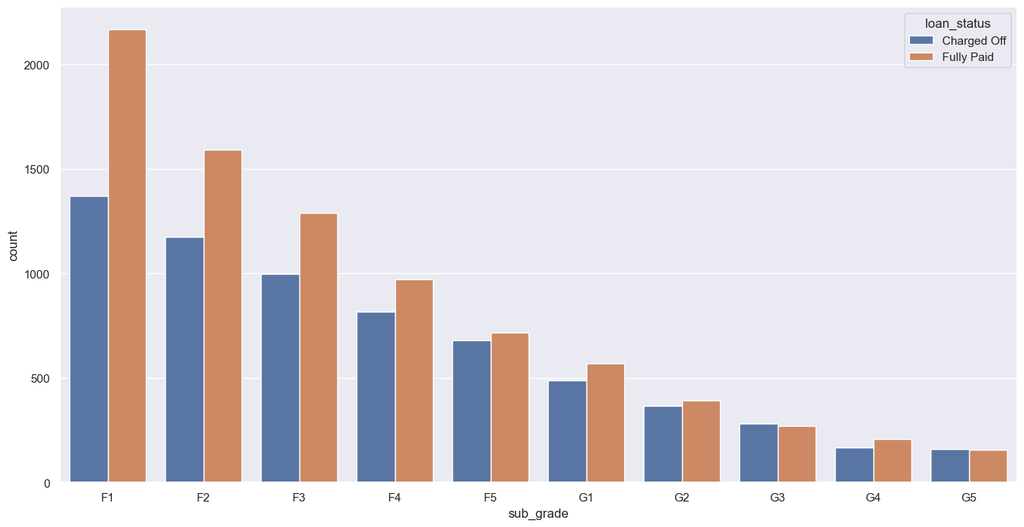

```python
sns.countplot(data= df[df['sub_grade'].str.contains('F|G')].sort_values('sub_grade'),
              x = 'sub_grade',
              hue= 'loan_status')
plt.show()
```

## On transforme loan_status en variable dummy dans une nouvelle feature load_repaid

```python
df['loan_status'].unique()
```

```
array(['Fully Paid', 'Charged Off'], dtype=object)
```

```python
df['loan_repaid'] = df['loan_status'].map({'Fully Paid': 1,
                                           'Charged Off': 0,})
df[['loan_repaid', 'loan_status']]
```

|  | loan_repaid | loan_status |
| --- | --- | --- |
| 0 | 1 | Fully Paid |
| 1 | 1 | Fully Paid |
| 2 | 1 | Fully Paid |
| 3 | 1 | Fully Paid |
| 4 | 0 | Charged Off |
| ... | ... | ... |
| 396025 | 1 | Fully Paid |
| 396026 | 1 | Fully Paid |
| 396027 | 1 | Fully Paid |
| 396028 | 1 | Fully Paid |
| 396029 | 1 | Fully Paid |

396030 rows × 2 columns

## Corrélation entre la nouvelle feature et les autres fetaures numérique

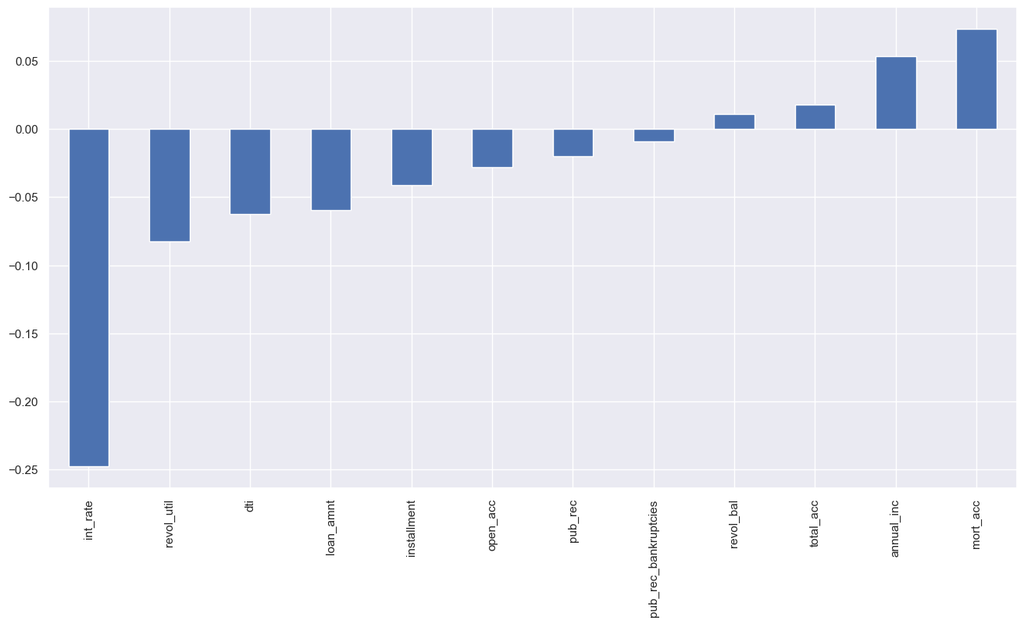

```python
df.corr()['loan_repaid'][:-1].sort_values().plot(kind= 'bar')
plt.show()
```

# 2 - Pré-traitement des Données

## Données manquantes

```python
print(f'Le Dataframe comporte {len(df)} lignes')
```

```
Le Dataframe comporte 396030 lignes
```

### Nombre de données manquantes par features

```python
df.isnull().sum().sort_values(ascending= False)
```

```
mort_acc                37795
emp_title               22927
emp_length              18301
title                    1755
pub_rec_bankruptcies      535
revol_util                276
dti                         0
address                     0
application_type            0
initial_list_status         0
total_acc                   0
revol_bal                   0
pub_rec                     0
open_acc                    0
earliest_cr_line            0
loan_amnt                   0
term                        0
purpose                     0
loan_status                 0
issue_d                     0
verification_status         0
annual_inc                  0
home_ownership              0
sub_grade                   0
grade                       0
installment                 0
int_rate                    0
loan_repaid                 0
dtype: int64
```

### Données manquantes en pourcentage

```python
100 * df.isnull().sum()/len(df)
```

```
loan_amnt               0.000000
term                    0.000000
int_rate                0.000000
installment             0.000000
grade                   0.000000
sub_grade               0.000000
emp_title               5.789208
emp_length              4.621115
home_ownership          0.000000
annual_inc              0.000000
verification_status     0.000000
issue_d                 0.000000
loan_status             0.000000
purpose                 0.000000
title                   0.443148
dti                     0.000000
earliest_cr_line        0.000000
open_acc                0.000000
pub_rec                 0.000000
revol_bal               0.000000
revol_util              0.069692
total_acc               0.000000
initial_list_status     0.000000
application_type        0.000000
mort_acc                9.543469
pub_rec_bankruptcies    0.135091
address                 0.000000
loan_repaid             0.000000
dtype: float64
```

On traite le problème dans l'ordre des features

### emp_title

```python
df['emp_title'].nunique()
```

```
173105
```

```python
df['emp_title'].value_counts()
```

```
Teacher                    4389
Manager                    4250
Registered Nurse           1856
RN                         1846
Supervisor                 1830
                           ...
Postman                       1
McCarthy & Holthus, LLC       1
jp flooring                   1
Histology Technologist        1
Gracon Services, Inc          1
Name: emp_title, Length: 173105, dtype: int64
```

Il y a trop de valeurs uniques pour les convertir en dummuies, on supprime donc la feature

```python
df.drop('emp_title', axis=1, inplace=True)
```

### emp_length

```python
list(df.emp_length.sort_values().unique())
```

```
['1 year',
 '10+ years',
 '2 years',
 '3 years',
 '4 years',
 '5 years',
 '6 years',
 '7 years',
 '8 years',
 '9 years',
 '< 1 year',
 nan]
```

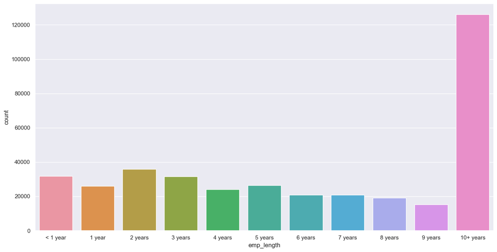

```python
emp_length_order= ['< 1 year', '1 year', '2 years','3 years','4 years','5 years','6 years','7 years','8 years','9 years','10+ years']

sns.countplot(data= df,
              x= 'emp_length',
              order= emp_length_order)
plt.show()
```

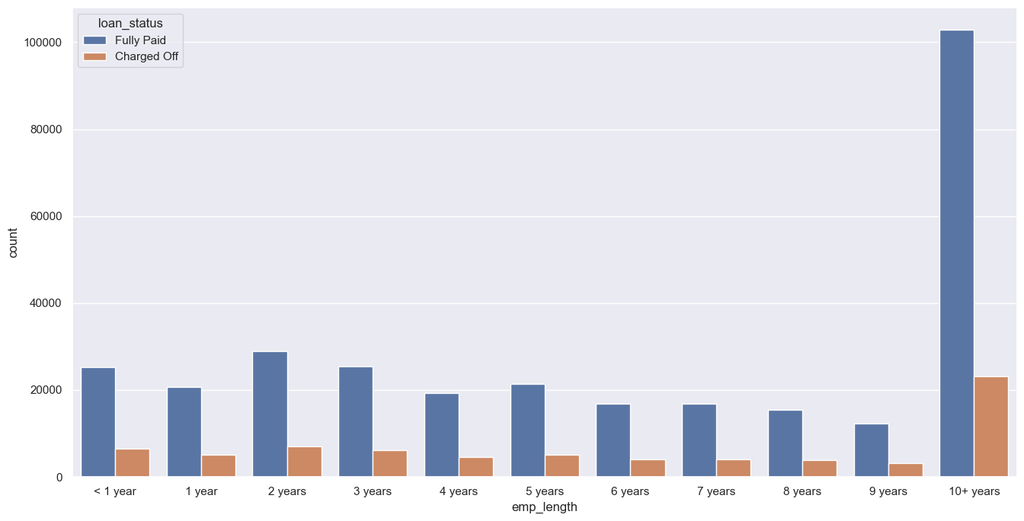

```python
sns.countplot(data= df,
              x= 'emp_length',
              hue= 'loan_status',
              order= emp_length_order)
plt.show()
```

Pourcentage de prêts non-remboursés par durée

```python
df_pivot = df.groupby(['emp_length', 'loan_status'])[['annual_inc']].count().reset_index().pivot_table(values='annual_inc',
                                                                                                       index= 'emp_length',
                                                                                                       columns= 'loan_status')
df_pivot['Charged Off']/df_pivot['Fully Paid']
```

```
emp_length
1 year       0.248649
10+ years    0.225770
2 years      0.239560
3 years      0.242593
4 years      0.238213
5 years      0.237911
6 years      0.233341
7 years      0.241887
8 years      0.249625
9 years      0.250735
< 1 year     0.260830
dtype: float64
```

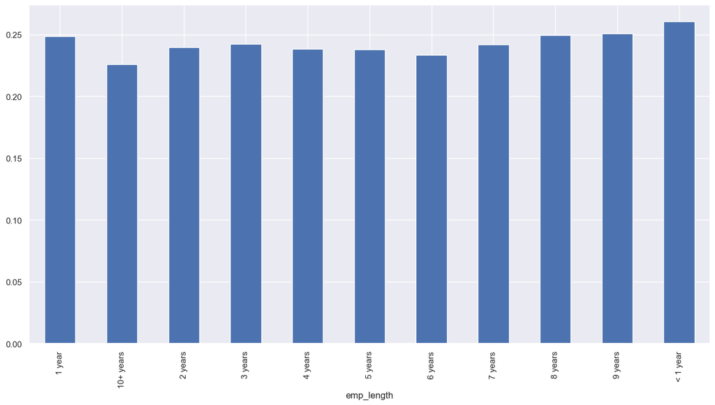

```python
(df_pivot['Charged Off']/df_pivot['Fully Paid']).plot(kind= 'bar')
plt.show()
```

Il y a une très faible corrélation entre la durée et le taux de remboursement, on supprime donc la variable

```python
df.drop('emp_length', axis=1, inplace=True)
```

### Title

```python
df.isnull().sum()[df.isnull().sum()>0]
```

```
title                    1755
revol_util                276
mort_acc                37795
pub_rec_bankruptcies      535
dtype: int64
```

```python
df.head(5).T
```

|  | 0 | 1 | 2 | 3 | 4 |
| --- | --- | --- | --- | --- | --- |
| loan_amnt | 10000.0 | 8000.0 | 15600.0 | 7200.0 | 24375.0 |
| term | 36 months | 36 months | 36 months | 36 months | 60 months |
| int_rate | 11.44 | 11.99 | 10.49 | 6.49 | 17.27 |
| installment | 329.48 | 265.68 | 506.97 | 220.65 | 609.33 |
| grade | B | B | B | A | C |
| sub_grade | B4 | B5 | B3 | A2 | C5 |
| home_ownership | RENT | MORTGAGE | RENT | RENT | MORTGAGE |
| annual_inc | 117000.0 | 65000.0 | 43057.0 | 54000.0 | 55000.0 |
| verification_status | Not Verified | Not Verified | Source Verified | Not Verified | Verified |
| issue_d | Jan-2015 | Jan-2015 | Jan-2015 | Nov-2014 | Apr-2013 |
| loan_status | Fully Paid | Fully Paid | Fully Paid | Fully Paid | Charged Off |
| purpose | vacation | debt_consolidation | credit_card | credit_card | credit_card |
| title | Vacation | Debt consolidation | Credit card refinancing | Credit card refinancing | Credit Card Refinance |
| dti | 26.24 | 22.05 | 12.79 | 2.6 | 33.95 |
| earliest_cr_line | Jun-1990 | Jul-2004 | Aug-2007 | Sep-2006 | Mar-1999 |
| open_acc | 16.0 | 17.0 | 13.0 | 6.0 | 13.0 |
| pub_rec | 0.0 | 0.0 | 0.0 | 0.0 | 0.0 |
| revol_bal | 36369.0 | 20131.0 | 11987.0 | 5472.0 | 24584.0 |
| revol_util | 41.8 | 53.3 | 92.2 | 21.5 | 69.8 |
| total_acc | 25.0 | 27.0 | 26.0 | 13.0 | 43.0 |
| initial_list_status | w | f | f | f | f |
| application_type | INDIVIDUAL | INDIVIDUAL | INDIVIDUAL | INDIVIDUAL | INDIVIDUAL |
| mort_acc | 0.0 | 3.0 | 0.0 | 0.0 | 1.0 |
| pub_rec_bankruptcies | 0.0 | 0.0 | 0.0 | 0.0 | 0.0 |
| address | 0174 Michelle Gateway\r\nMendozaberg, OK 22690 | 1076 Carney Fort Apt. 347\r\nLoganmouth, SD 05113 | 87025 Mark Dale Apt. 269\r\nNew Sabrina, WV 05113 | 823 Reid Ford\r\nDelacruzside, MA 00813 | 679 Luna Roads\r\nGreggshire, VA 11650 |
| loan_repaid | 1 | 1 | 1 | 1 | 0 |

On observe des similitudes entre title et purpose

```python
df[['purpose', 'title']].head(10)
```

|  | purpose | title |
| --- | --- | --- |
| 0 | vacation | Vacation |
| 1 | debt_consolidation | Debt consolidation |
| 2 | credit_card | Credit card refinancing |
| 3 | credit_card | Credit card refinancing |
| 4 | credit_card | Credit Card Refinance |
| 5 | debt_consolidation | Debt consolidation |
| 6 | home_improvement | Home improvement |
| 7 | credit_card | No More Credit Cards |
| 8 | debt_consolidation | Debt consolidation |
| 9 | debt_consolidation | Debt Consolidation |

```python
df['purpose'].nunique()
```

```
14
```

```python
df['title'].nunique()
```

```
48817
```

```python
len(df[['purpose', 'title']].value_counts())
```

```
54958
```

title est une sous-catégorie de purpose avec trop de valeurs pour la transformer en dummy, on l'a supprime

```python
df.drop('title', axis=1, inplace=True)
```

### mort_acc

```python
df.isnull().sum()[df.isnull().sum()>0]
```

```
revol_util                276
mort_acc                37795
pub_rec_bankruptcies      535
dtype: int64
```

Trop de valeurs manquantes pour supprimer la feature

Distribution de mort_acc

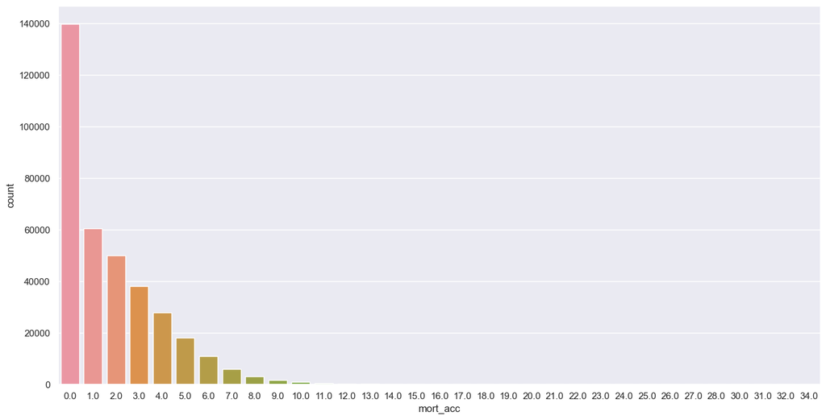

```python
sns.countplot(data= df,
              x= 'mort_acc')
plt.show()
```

```python
df.mort_acc.value_counts()
```

```
0.0     139777
1.0      60416
2.0      49948
3.0      38049
4.0      27887
5.0      18194
6.0      11069
7.0       6052
8.0       3121
9.0       1656
10.0       865
11.0       479
12.0       264
13.0       146
14.0       107
15.0        61
16.0        37
17.0        22
18.0        18
19.0        15
20.0        13
24.0        10
22.0         7
21.0         4
25.0         4
27.0         3
32.0         2
31.0         2
23.0         2
26.0         2
28.0         1
30.0         1
34.0         1
Name: mort_acc, dtype: int64
```

```python
df.corr()['mort_acc'].sort_values()[:-1]
```

```
int_rate               -0.082583
dti                    -0.025439
revol_util              0.007514
pub_rec                 0.011552
pub_rec_bankruptcies    0.027239
loan_repaid             0.073111
open_acc                0.109205
installment             0.193694
revol_bal               0.194925
loan_amnt               0.222315
annual_inc              0.236320
total_acc               0.381072
Name: mort_acc, dtype: float64
```

Il y a une corrélation entre mort_acc et total_acc, on peut donc l'utiliser pour compléter les valeurs manquantes.

```python
total_acc_mean = df.groupby('total_acc')['mort_acc'].mean()
total_acc_mean
```

```
total_acc
2.0      0.000000
3.0      0.052023
4.0      0.066743
5.0      0.103289
6.0      0.151293
           ...
124.0    1.000000
129.0    1.000000
135.0    3.000000
150.0    2.000000
151.0    0.000000
Name: mort_acc, Length: 118, dtype: float64
```

```python
def fill_mort_acc(total_acc, mort_acc):
    return total_acc_mean[total_acc] if np.isnan(mort_acc) else mort_acc
```

```python
df['mort_acc'] = df.apply(lambda x: fill_mort_acc(x['total_acc'],
                                                  x['mort_acc']),
                          axis= 1)
```

```python
df.isnull().sum()[df.isnull().sum()>0]
```

```
revol_util              276
pub_rec_bankruptcies    535
dtype: int64
```

### revol_util et pub_rec_bankruptcies

Il y a peu de valeurs manquantes, nous pouvons simplement supprimer les lignes concernées

```python
df.dropna(inplace= True)
```

```python
df.isnull().sum()[df.isnull().sum()>0]
```

```
Series([], dtype: int64)
```

## Pré-traitement des variables catégorielles pour ANN

```python
df.select_dtypes(['object']).columns
```

```
Index(['term', 'grade', 'sub_grade', 'home_ownership', 'verification_status',
       'issue_d', 'loan_status', 'purpose', 'earliest_cr_line',
       'initial_list_status', 'application_type', 'address'],
      dtype='object')
```

### Term

```python
df.term.value_counts()
```

```
 36 months    301247
 60 months     93972
Name: term, dtype: int64
```

Nous pouvons convertir en nombre

```python
df['term'] = df['term'].str[:3].astype(int)
```

```python
df['term'].value_counts()
```

```
36    301247
60     93972
Name: term, dtype: int64
```

### grade

grade fait partie de sub_grade, nous pouvons supprimer la feature

```python
df.drop(columns=['grade'], inplace= True)
```

### sub_grade

```python
df.sub_grade.nunique()
```

```
35
```

Avec 35 valeurs uniques, nous pouvons transformer la feature en dummy

```python
subgrade_dummies = pd.get_dummies(df.sub_grade,
                                  drop_first= True)
```

```python
df = pd.concat([df.drop('sub_grade', axis=1),
                subgrade_dummies], axis= 1)
```

### verification_status, application_type, initial_list_status, purpose

```python
for i in ['verification_status', 'application_type', 'initial_list_status', 'purpose']:
    print(f'{i} = {df[i].nunique()}')
```

```
verification_status = 3
application_type = 3
initial_list_status = 2
purpose = 14
```

Il y a peu de valeurs uniques, nous pouvons convertir en dummies

```python
others_dummies = pd.get_dummies(df[['verification_status', 'application_type', 'initial_list_status', 'purpose']],
                                drop_first= True)

df = df.drop(['verification_status', 'application_type', 'initial_list_status', 'purpose'],
             axis= 1)

df = pd.concat([df,
                others_dummies], axis= 1)
```

```python
len(df.columns)
```

```
71
```

### home_ownership

```python
df.home_ownership.unique()
```

```
array(['RENT', 'MORTGAGE', 'OWN', 'OTHER', 'ANY', 'NONE'], dtype=object)
```

```python
df.home_ownership.value_counts()
```

```
MORTGAGE    198022
RENT        159395
OWN          37660
OTHER          110
NONE            29
ANY              3
Name: home_ownership, dtype: int64
```

Nous pouvons réduire le nombre de valeurs en incluant NONE et ANY dans OTHER

```python
df.home_ownership = df.home_ownership.replace(['NONE','ANY'], 'OTHER')
```

```python
home_ownership_dummies = pd.get_dummies(df.home_ownership, drop_first= True)
df = df.drop('home_ownership', axis= 1)
df = pd.concat([df, home_ownership_dummies], axis= 1)
```

```python
len(df.columns)
```

```
73
```

### address

```python
df.address.unique()
```

```
array(['0174 Michelle Gateway\r\nMendozaberg, OK 22690',
       '1076 Carney Fort Apt. 347\r\nLoganmouth, SD 05113',
       '87025 Mark Dale Apt. 269\r\nNew Sabrina, WV 05113', ...,
       '953 Matthew Points Suite 414\r\nReedfort, NY 70466',
       '7843 Blake Freeway Apt. 229\r\nNew Michael, FL 29597',
       '787 Michelle Causeway\r\nBriannaton, AR 48052'], dtype=object)
```

```python
df.address.value_counts()
```

```
USCGC Smith\r\nFPO AE 70466                            8
USS Smith\r\nFPO AP 70466                              8
USS Johnson\r\nFPO AE 48052                            8
USNS Johnson\r\nFPO AE 05113                           8
USNS Johnson\r\nFPO AP 48052                           7
                                                      ..
43570 Maxwell Field Apt. 502\r\nEast John, NH 22690    1
9983 Turner Cove\r\nSouth Gregmouth, WV 70466          1
1312 Cody Shoal\r\nRalphfurt, CO 29597                 1
3841 Liu Crest\r\nClarkchester, NC 29597               1
787 Michelle Causeway\r\nBriannaton, AR 48052          1
Name: address, Length: 392898, dtype: int64
```

```python
df.address.nunique()
```

```
392898
```

```python
df.address.head(10)
```

```
0       0174 Michelle Gateway\r\nMendozaberg, OK 22690
1    1076 Carney Fort Apt. 347\r\nLoganmouth, SD 05113
2    87025 Mark Dale Apt. 269\r\nNew Sabrina, WV 05113
3              823 Reid Ford\r\nDelacruzside, MA 00813
4               679 Luna Roads\r\nGreggshire, VA 11650
5    1726 Cooper Passage Suite 129\r\nNorth Deniseb...
6    1008 Erika Vista Suite 748\r\nEast Stephanie, ...
7                          USCGC Nunez\r\nFPO AE 30723
8                           USCGC Tran\r\nFPO AP 22690
9               3390 Luis Rue\r\nMauricestad, VA 00813
Name: address, dtype: object
```

Nous pouvons extraire le zip code de adress dans une nouvelle feature zip_cide

```python
df['zip_code'] = df.address.str[-5:]
```

```python
df.zip_code.value_counts()
```

```
70466    56880
22690    56413
30723    56402
48052    55811
00813    45725
29597    45393
05113    45300
11650    11210
93700    11126
86630    10959
Name: zip_code, dtype: int64
```

```python
df.zip_code.nunique()
```

```
10
```

Avec 10 valeurs uniques, nous pouvons transformer la feature en dummy

```python
zip_code_dummies = pd.get_dummies(df.zip_code, drop_first= True)
df = df.drop('zip_code', axis= 1)
df = pd.concat([df, zip_code_dummies], axis= 1)
```

```python
len(df.columns)
```

```
82
```

```python
df.columns[-10:]
```

```
Index(['RENT', '05113', '11650', '22690', '29597', '30723', '48052', '70466',
       '86630', '93700'],
      dtype='object')
```

```python
df.drop('address', axis= 1, inplace= True)
```

### issue_d

La date d'émission du prêt est déterminée seulement après que ce dernier soit accordé ou non, donc la feature doit être exclue du model

```python
df.drop('issue_d', axis= 1, inplace= True)
```

### earliest_cr_line

```python
df.earliest_cr_line
```

```
0         Jun-1990
1         Jul-2004
2         Aug-2007
3         Sep-2006
4         Mar-1999
            ...
396025    Nov-2004
396026    Feb-2006
396027    Mar-1997
396028    Nov-1990
396029    Sep-1998
Name: earliest_cr_line, Length: 395219, dtype: object
```

Nous pouvont extraire l'année

```python
df.earliest_cr_line = df.earliest_cr_line.str[-4:].astype(int)
df.earliest_cr_line.value_counts()
```

```
2000    29302
2001    29031
1999    26444
2002    25849
2003    23623
        ...
1951        3
1950        3
1953        2
1944        1
1948        1
Name: earliest_cr_line, Length: 65, dtype: int64
```

Inutile de transformer en dummy car il s'agit d'une variable continue

## Répartition Entraînement / Test

```python
from sklearn.model_selection import train_test_split
```

```python
# Doublon de loan_repaid
df.drop('loan_status', axis= 1, inplace= True)
```

```python
X = df.drop('loan_repaid', axis= 1).values
y = df.loan_repaid.values
```

```python
X_train, X_test, y_train, y_test = train_test_split(X, y, test_size=0.2, random_state=101)
```

## Normalisation des données

```python
from sklearn.preprocessing import MinMaxScaler
```

```python
scaler = MinMaxScaler()
```

```python
X_train = scaler.fit_transform(X_train)
```

```python
X_test = scaler.transform(X_test)
```

# 3 - Création du Modèle

```python
import tensorflow as tf
from tensorflow.keras.models import Sequential
from tensorflow.keras.layers import Dense, Dropout
from tensorflow.keras.callbacks import EarlyStopping
```

```python
X_train.shape
```

```
(316175, 78)
```

```python
early_stop = EarlyStopping(monitor='val_loss',
                           mode= 'min',
                           verbose= 1,
                           patience= 25)
```

```python
model = Sequential()

model.add(Dense(78, activation= 'relu'))
model.add(Dropout(0.2))

model.add(Dense(39, activation= 'relu'))
model.add(Dropout(0.2))

model.add(Dense(19, activation= 'relu'))
model.add(Dropout(0.2))

model.add(Dense(units= 1, activation= 'sigmoid'))

model.compile(loss= 'binary_crossentropy', optimizer= 'adam')
```

```python
model.fit(x= X_train,
               y= y_train,
               epochs= 200,
               batch_size= 1024,
               validation_data= (X_test,
                                 y_test),
               callbacks= [early_stop])
```

```
Epoch 80: early stopping
```

```
<keras.callbacks.History at 0x447a07c0>
```

```python
from datetime import datetime
```

```python
now = datetime.now()
model.save(f'Models/{now.year}-{now.month}-{now.day}_{now.hour}-{now.minute}_model.h5')
```

# 4 - Évaluation de la performance du modèle

```python
from sklearn.metrics import classification_report, confusion_matrix, ConfusionMatrixDisplay
```

## Over et under-fitting

```python
loss_stats = pd.DataFrame(model.history.history)
```

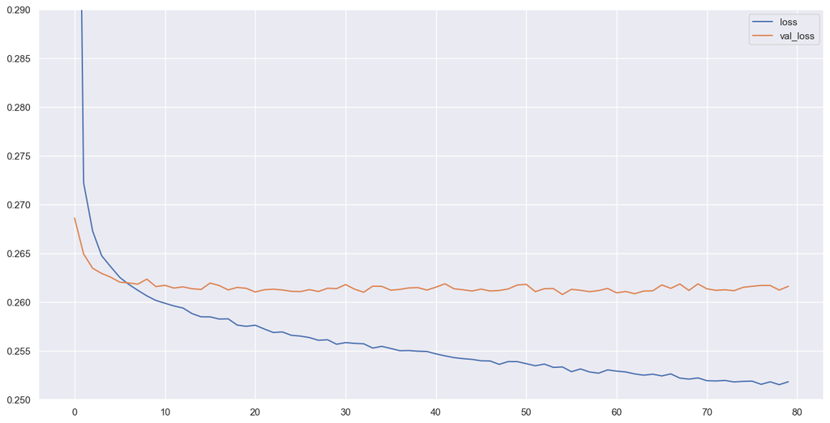

```python
loss_stats[['loss','val_loss']].plot()
plt.ylim(0.25, 0.29)
plt.show()
```

## Precision, recall & accuracy

```python
100 * df.loan_repaid.value_counts()/len(df)
```

```
1    80.384799
0    19.615201
Name: loan_repaid, dtype: float64
```

Les données sont déséquilibrées, nous allons donc nous concentrer sur precision et recall

```python
predictions_5 = (model.predict(X_test) > 0.5).astype(int)
```

```python
print(classification_report(y_test, predictions_5))
```

```
              precision    recall  f1-score   support

           0       0.92      0.48      0.63     15658
           1       0.88      0.99      0.93     63386

    accuracy                           0.89     79044
   macro avg       0.90      0.73      0.78     79044
weighted avg       0.89      0.89      0.87     79044
```

# 5 - Test de validation

```python
import random
```

```python
def loan_prediction(customer, model):
    customer_trans = scaler.transform(customer.values.reshape(1,78))
    return model.predict(customer_trans, verbose=0)
```

```python
def validation_test(nb, model, bool, df, bins):
    """
    Args:
        nb (int): echantillon
        model (): modèle utilisé
        bool (int): 0: negatif | 1: positif
        df (df):
        bins (int):

    Returns:
        sns: histplot
    """
    res = []
    use_df = df.query(f'loan_repaid == {bool}')
    for i in range(nb):
        rand_index = random.randint(0, len(use_df))
        rand_customer = use_df.drop('loan_repaid', axis= 1).iloc[rand_index]
        res.append(loan_prediction(rand_customer, model)[0][0])

    fig = sns.histplot(pd.DataFrame({'Result': res}),
                       x= 'Result',
                       bins= bins)

    return pd.DataFrame({'Result': res})
```

## Résulat avec des labels positifs

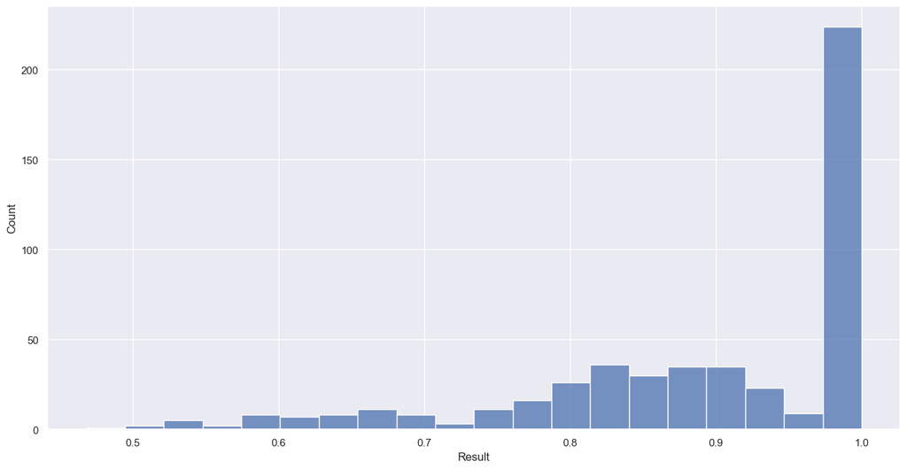

```python
df_vrai = validation_test(500, model, 1, df, 20)
```

```python
score_vrai_5 = 100 * len(df_vrai.query('Result > 0.5'))/len(df_vrai)
print(f'Les résulats sont très bons avec {score_vrai_5} % de réponses correctes')
```

```
Les résulats sont très bons avec 99.6 % de réponses correctes
```

## Résulat avec des labels négatifs

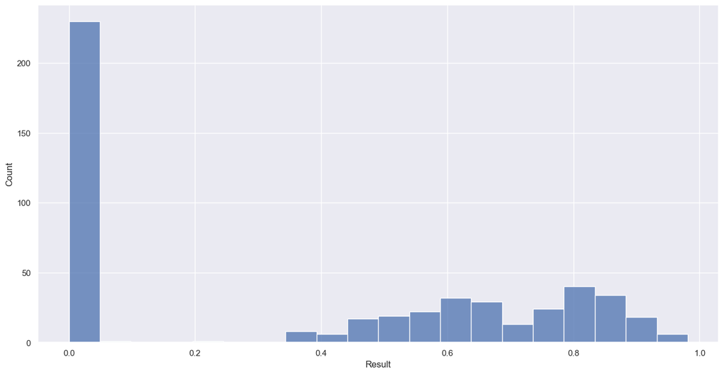

```python
df_faux = validation_test(500, model, 0, df, 20)
```

```python
score_faux_5 = 100 * len(df_faux.query('Result < 0.5'))/len(df_vrai)
print(f'Les résulats sont mauvais avec {score_faux_5} % de réponses correctes')
```

```
Les résulats sont mauvais avec 53.2 % de réponses correctes
```

## Comparaison

```python
df_vrai['label'] = 'Oui'
df_vrai.sort_values('Result', inplace= True)

df_faux['label'] = 'Non'
df_faux.sort_values('Result', inplace= True)
```

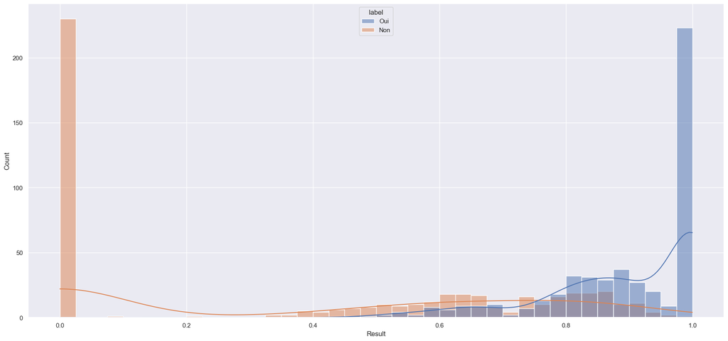

```python
plt.figure(figsize= (22, 10))

sns.histplot(data= pd.concat([df_vrai, df_faux], ignore_index=True),
             x= 'Result',
             hue= 'label',
             bins= 40,
             alpha= 0.5,
             kde=True)

plt.show()
```

Un moyen d'améliorer le modèle serait d'augmenter le seuil de classification.

Les résulats seront moins bons sur les labels positifs mais meilleurs sur les négatifs.  
Ce n'est pas un problème car il parrait plus dangereux d'accorder un prêt qui ne sera pas remboursé plutôt que de refuser un prêt valable.